# Lab 4 - Árboles de Regresión

Jose Sanchez, Roberto Najera y Andre Pivaral

2026-03-24

# 1 Introducción

SmartStay Advisors es una firma intermediaria que facilita la búsqueda y selección de propiedades en Airbnb para clientes corporativos y particulares. El objetivo de este laboratorio es construir un **árbol de regresión** para predecir el precio por noche de las propiedades, usando los mismos conjuntos de entrenamiento y prueba del laboratorio anterior (regresión lineal), y comparar su desempeño.

# 2 Actividad 1: Conjuntos de Entrenamiento y Prueba

Se utilizan exactamente los mismos datos, semilla y partición que en el laboratorio anterior para garantizar comparabilidad entre modelos.

```r
library(tidyverse)
library(rpart)
library(rpart.plot)
library(scales)
library(knitr)
```

```r
load("C:/Users/jrss3/OneDrive/Escritorio/1ER Semestre 2026/Mineria de Datos/lab3MD/listings.RData")

# Misma limpieza que lab 3
listings <- listings %>%
  mutate(price_num = as.numeric(gsub("[$,]", "", price)))

p1  <- quantile(listings$price_num, 0.01, na.rm = TRUE)
p99 <- quantile(listings$price_num, 0.99, na.rm = TRUE)

listings_clean <- listings %>%
  filter(!is.na(price_num),
         price_num >= p1, price_num <= p99,
         !is.na(review_scores_rating),
         !is.na(bedrooms),
         !is.na(accommodates))
```

```r
set.seed(123)   # misma semilla que lab 3

datos_modelo <- listings_clean %>%
  select(price_num, accommodates, bedrooms, beds,
         review_scores_rating, reviews_per_month,
         minimum_nights, availability_365) %>%
  drop_na()

n           <- nrow(datos_modelo)
train_index <- sample(seq_len(n), size = 0.8 * n)

train_data <- datos_modelo[train_index, ]
test_data  <- datos_modelo[-train_index, ]

cat("Filas entrenamiento:", nrow(train_data), "\n")
```

```
## Filas entrenamiento: 49656
```

```r
cat("Filas prueba:       ", nrow(test_data),  "\n")
```

```
## Filas prueba:        12415
```

Los conjuntos de datos reproducen exactamente la partición usada en el laboratorio anterior (semilla `123`, 80 % entrenamiento / 20 % prueba).

# 3 Actividad 2: Árbol de Regresión

Se construye un árbol de regresión con `rpart` usando todas las variables disponibles del dataset de modelado. El parámetro `cp = 0.001` permite que el árbol crezca con suficiente detalle antes de podarlo.

```r
set.seed(123)

arbol_reg <- rpart(
  price_num ~ .,
  data    = train_data,
  method  = "anova",
  control = rpart.control(
    cp      = 0.001,   # complejidad mínima para dividir
    minsplit = 20,     # mínimo de observaciones para dividir un nodo
    maxdepth = 6       # profundidad máxima del árbol
  )
)
```

## 3.1 Poda del árbol (selección de cp óptimo)

Para evitar sobreajuste se selecciona el valor de `cp` que minimiza el error de validación cruzada.

```r
# Tabla de complejidad
printcp(arbol_reg)
```

```
##
## Regression tree:
## rpart(formula = price_num ~ ., data = train_data, method = "anova",
##     control = rpart.control(cp = 0.001, minsplit = 20, maxdepth = 6))
##
## Variables actually used in tree construction:
## [1] accommodates         availability_365     bedrooms
## [4] beds                 minimum_nights       review_scores_rating
## [7] reviews_per_month
##
## Root node error: 1.27e+10/49656 = 255765
##
## n= 49656
##
##           CP nsplit rel error  xerror     xstd
```

[output cut: 25 more lines]

```r
# cp óptimo: el que minimiza xerror
cp_optimo <- arbol_reg$cptable[which.min(arbol_reg$cptable[, "xerror"]), "CP"]
cat("\ncp óptimo:", round(cp_optimo, 6), "\n")
```

```
##
## cp óptimo: 0.001
```

```r
# Podar el árbol
arbol_podado <- prune(arbol_reg, cp = cp_optimo)
```

## 3.2 Visualización del árbol

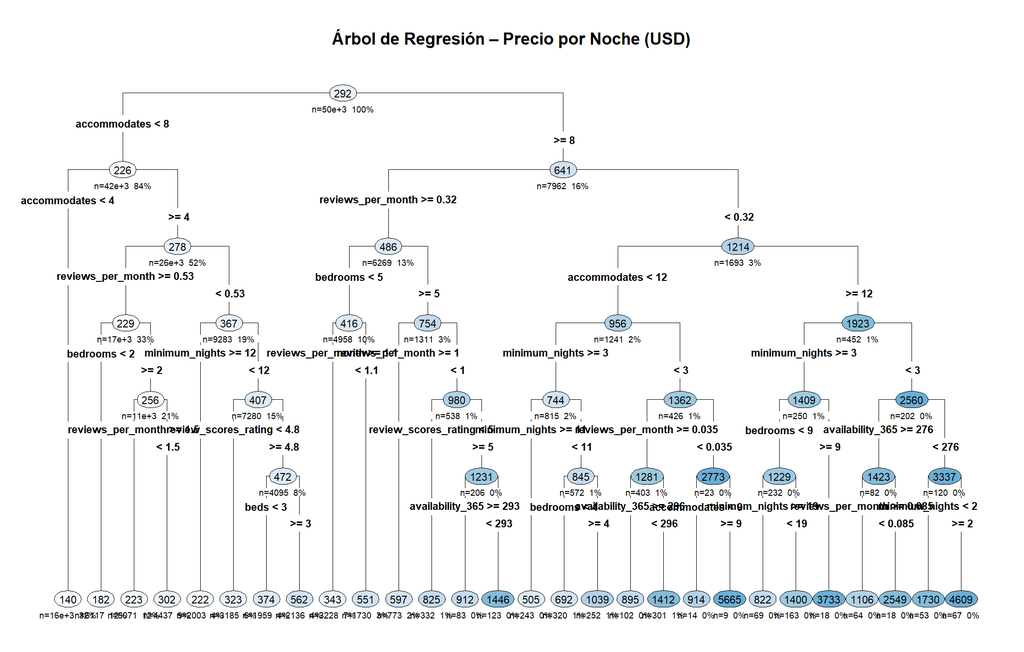

```r
rpart.plot(
  arbol_podado,
  type    = 4,
  extra   = 101,
  under   = TRUE,
  fallen.leaves = TRUE,
  main    = "Árbol de Regresión – Precio por Noche (USD)",
  cex     = 0.7,
  box.palette = "Blues"
)
```

## 3.3 Importancia de variables

```r
importancia <- as.data.frame(arbol_podado$variable.importance)
importancia <- data.frame(
  variable    = rownames(importancia),
  importancia = importancia[, 1]
) %>%
  arrange(desc(importancia)) %>%
  mutate(importancia_rel = round(importancia / sum(importancia) * 100, 1))

kable(importancia,
      col.names = c("Variable", "Importancia absoluta", "Importancia relativa (%)"),
      caption   = "Importancia de variables en el árbol de regresión")
```

Importancia de variables en el árbol de regresión

| Variable | Importancia absoluta | Importancia relativa (%) |
| --- | --- | --- |
| accommodates | 1854586864 | 29.7 |
| bedrooms | 1159583909 | 18.6 |
| beds | 1067856516 | 17.1 |
| reviews_per_month | 1016018482 | 16.3 |
| minimum_nights | 704201053 | 11.3 |
| availability_365 | 328040665 | 5.3 |
| review_scores_rating | 116962336 | 1.9 |

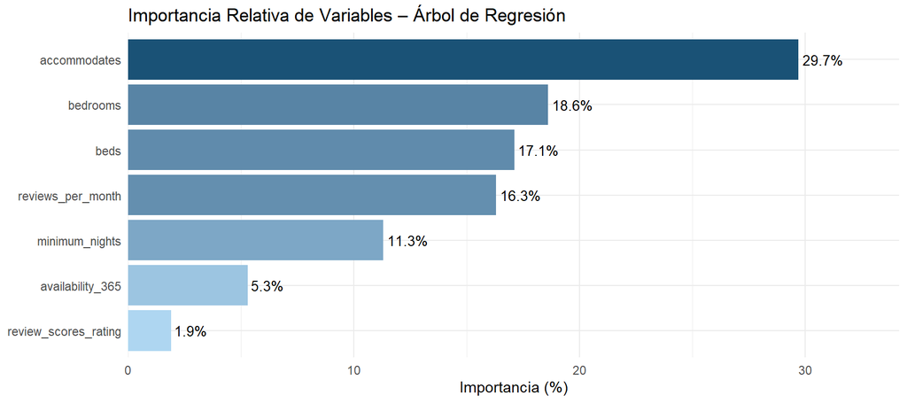

```r
ggplot(importancia, aes(x = reorder(variable, importancia_rel), y = importancia_rel,
                        fill = importancia_rel)) +
  geom_col(show.legend = FALSE) +
  geom_text(aes(label = paste0(importancia_rel, "%")), hjust = -0.1, size = 3.5) +
  coord_flip() +
  scale_fill_gradient(low = "#AED6F1", high = "#1A5276") +
  scale_y_continuous(expand = expansion(mult = c(0, 0.15))) +
  labs(title  = "Importancia Relativa de Variables – Árbol de Regresión",
       x = NULL, y = "Importancia (%)") +
  theme_minimal()
```

# 4 Actividad 3: Predicción y Análisis de Resultados

## 4.1 Predicciones sobre el conjunto de prueba

```r
pred_arbol <- predict(arbol_podado, newdata = test_data)

rmse_arbol <- sqrt(mean((test_data$price_num - pred_arbol)^2))
mae_arbol  <- mean(abs(test_data$price_num  - pred_arbol))
r2_arbol   <- cor(test_data$price_num, pred_arbol)^2

cat("=== Métricas del árbol de regresión (conjunto de prueba) ===\n")
```

```
## === Métricas del árbol de regresión (conjunto de prueba) ===
```

```r
cat("RMSE:", round(rmse_arbol, 2), "\n")
```

```
## RMSE: 424.64
```

```r
cat("MAE: ", round(mae_arbol,  2), "\n")
```

```
## MAE:  151.47
```

```r
cat("R²:  ", round(r2_arbol,   4), "\n")
```

```
## R²:   0.366
```

## 4.2 Comparación con los modelos de regresión lineal (lab 3)

```r
# Métricas de referencia del laboratorio anterior (regresión lineal)
metricas_lab3 <- tibble(
  Modelo = c("Regresión Simple", "Regresión Múltiple", "Stepwise (AIC)",
             "Modelo Final", "Ridge", "Lasso", "ElasticNet"),
  RMSE   = c(131.07, 116.88, 116.88, 117.01, 116.91, 117.52, 116.89),
  MAE    = c( 88.15,  77.42,  77.42,  77.52,  77.47,  77.98,  77.44),
  R2     = c(  0.14,   0.24,   0.24,   0.24,   0.24,   0.23,   0.24)
)

comparacion <- metricas_lab3 %>%
  add_row(
    Modelo = "Árbol de Regresión",
    RMSE   = round(rmse_arbol, 2),
    MAE    = round(mae_arbol,  2),
    R2     = round(r2_arbol,   4)
  ) %>%
  arrange(RMSE)

kable(comparacion,
      col.names = c("Modelo", "RMSE", "MAE", "R²"),
      caption   = "Comparación de modelos – Conjunto de prueba")
```

Comparación de modelos – Conjunto de prueba

| Modelo | RMSE | MAE | R² |
| --- | --- | --- | --- |
| Regresión Múltiple | 116.88 | 77.42 | 0.240 |
| Stepwise (AIC) | 116.88 | 77.42 | 0.240 |
| ElasticNet | 116.89 | 77.44 | 0.240 |
| Ridge | 116.91 | 77.47 | 0.240 |
| Modelo Final | 117.01 | 77.52 | 0.240 |
| Lasso | 117.52 | 77.98 | 0.230 |
| Regresión Simple | 131.07 | 88.15 | 0.140 |
| Árbol de Regresión | 424.64 | 151.47 | 0.366 |